# Preliminary data exploration

Author

Estela Moral

## Libraries

```r
library(tidyverse)
library(tidytext)
library(stm)
library(topicmodels)
library(igraph)
library(ggraph)
library(widyr)
library(kableExtra)
library(DT)
```

```r
load("DATA/parsed_df_clean.RData")
```

| doc_id | sentence_id | token_id | token | word | pos | date | agenda | party | party_full | speaker | term | start | end | start_year | end_year | year |
| --- | --- | --- | --- | --- | --- | --- | --- | --- | --- | --- | --- | --- | --- | --- | --- | --- |
| 96222 | 1 | 2 | presidenta | presidenta | NOUN | 2016-08-30 | DEBATE SOBRE LA INVESTIDURA DEL CANDIDATO A LA PRESIDENCIA. (Número de expediente 080/000001). | PP | Partido Popular | Rajoy Brey, Mariano | XII Legislatura (2016–2019) | 2016-07-19 | 2019-05-20 | 2016 | 2019 | 2016 |
| 96222 | 1 | 7 | razones | razón | NOUN | 2016-08-30 | DEBATE SOBRE LA INVESTIDURA DEL CANDIDATO A LA PRESIDENCIA. (Número de expediente 080/000001). | PP | Partido Popular | Rajoy Brey, Mariano | XII Legislatura (2016–2019) | 2016-07-19 | 2019-05-20 | 2016 | 2019 | 2016 |
| 96222 | 1 | 12 | aceptado | aceptar | VERB | 2016-08-30 | DEBATE SOBRE LA INVESTIDURA DEL CANDIDATO A LA PRESIDENCIA. (Número de expediente 080/000001). | PP | Partido Popular | Rajoy Brey, Mariano | XII Legislatura (2016–2019) | 2016-07-19 | 2019-05-20 | 2016 | 2019 | 2016 |
| 96222 | 1 | 14 | encargo | encargo | NOUN | 2016-08-30 | DEBATE SOBRE LA INVESTIDURA DEL CANDIDATO A LA PRESIDENCIA. (Número de expediente 080/000001). | PP | Partido Popular | Rajoy Brey, Mariano | XII Legislatura (2016–2019) | 2016-07-19 | 2019-05-20 | 2016 | 2019 | 2016 |
| 96222 | 1 | 17 | majestad | majestad | NOUN | 2016-08-30 | DEBATE SOBRE LA INVESTIDURA DEL CANDIDATO A LA PRESIDENCIA. (Número de expediente 080/000001). | PP | Partido Popular | Rajoy Brey, Mariano | XII Legislatura (2016–2019) | 2016-07-19 | 2019-05-20 | 2016 | 2019 | 2016 |
| 96222 | 1 | 19 | solicito | solicitar | VERB | 2016-08-30 | DEBATE SOBRE LA INVESTIDURA DEL CANDIDATO A LA PRESIDENCIA. (Número de expediente 080/000001). | PP | Partido Popular | Rajoy Brey, Mariano | XII Legislatura (2016–2019) | 2016-07-19 | 2019-05-20 | 2016 | 2019 | 2016 |
| 96222 | 1 | 21 | confianza | confianza | NOUN | 2016-08-30 | DEBATE SOBRE LA INVESTIDURA DEL CANDIDATO A LA PRESIDENCIA. (Número de expediente 080/000001). | PP | Partido Popular | Rajoy Brey, Mariano | XII Legislatura (2016–2019) | 2016-07-19 | 2019-05-20 | 2016 | 2019 | 2016 |
| 96222 | 1 | 27 | investidura | investidura | NOUN | 2016-08-30 | DEBATE SOBRE LA INVESTIDURA DEL CANDIDATO A LA PRESIDENCIA. (Número de expediente 080/000001). | PP | Partido Popular | Rajoy Brey, Mariano | XII Legislatura (2016–2019) | 2016-07-19 | 2019-05-20 | 2016 | 2019 | 2016 |
| 96222 | 1 | 32 | necesita | necesitar | VERB | 2016-08-30 | DEBATE SOBRE LA INVESTIDURA DEL CANDIDATO A LA PRESIDENCIA. (Número de expediente 080/000001). | PP | Partido Popular | Rajoy Brey, Mariano | XII Legislatura (2016–2019) | 2016-07-19 | 2019-05-20 | 2016 | 2019 | 2016 |
| 96222 | 1 | 34 | Gobierno | gobierno | PROPN | 2016-08-30 | DEBATE SOBRE LA INVESTIDURA DEL CANDIDATO A LA PRESIDENCIA. (Número de expediente 080/000001). | PP | Partido Popular | Rajoy Brey, Mariano | XII Legislatura (2016–2019) | 2016-07-19 | 2019-05-20 | 2016 | 2019 | 2016 |

## 1. TOP 15 most used words by year:

```r
word_freq <- parsed_df_clean |>
  count(year, word, sort = TRUE) |>
  group_by(year) |>
  slice_max(n, n = 15) |>
  ungroup()
```

|  | year | word | n |
| --- | --- | --- | --- |
| 1 | 2016 | gobierno | 2595 |
| 2 | 2016 | ley | 2046 |
| 3 | 2016 | partido | 2001 |
| 4 | 2016 | querer | 1720 |
| 5 | 2016 | país | 1673 |
| 6 | 2016 | español | 1407 |
| 7 | 2016 | grupo | 1315 |
| 8 | 2016 | política | 1315 |
| 9 | 2016 | hablar | 1164 |
| 10 | 2016 | popular | 1157 |

[output cut: 35 more lines]

## 2. TF-IDF

**Most distinctive words of each year**:

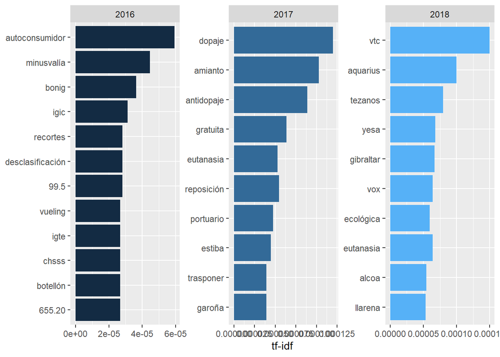

```r
tfidf_all <- parsed_df_clean |>
  count(year, word, sort = TRUE) |>
  bind_tf_idf(word, year, n) |>
  arrange(desc(tf_idf))

tfidf_all |>
  group_by(year) |>
  slice_max(tf_idf, n = 10) |>
  ungroup() |>
  ggplot(aes(tf_idf, fct_reorder(word, tf_idf), fill = year)) +
  geom_col(show.legend = FALSE) +
  facet_wrap(~ year, scales = "free") +
  labs(x = "tf-idf", y = NULL)
```

**Most distinctive words of each year by party**:

```r
unique(parsed_df_clean$party)
```

```
[1] "PP"        "PSOE"      "CUP-EC-EM" "Cs"        "ER"        "PNV"
[7] "DL"        "MX"
```

```r
party_colors <- c(
  "PSOE" = "#E30613",
  "PNV" = "#2A8343",
  "PP" = "#0093D8",
  "Cs" = "#FA4F00",
  "CUP-EC-EM" = "#693065",
  "ER" = "#FFBF41",
  "DL" = "#2E307A",
  "MX" = "#848484"
)
```

### 2016

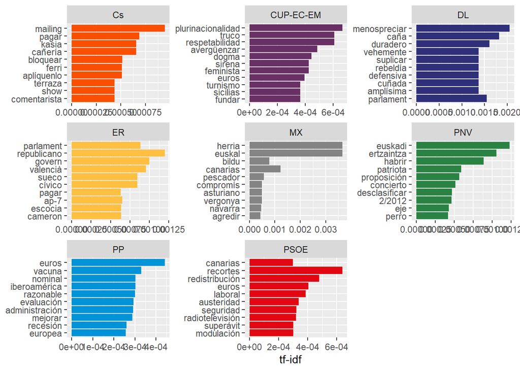

```r
speeches_2016 <- parsed_df_clean |>
  filter(year == 2016)

tfidf_2016 <- speeches_2016 |>
  count(party, word, sort = TRUE) |>
  bind_tf_idf(word, party, n) |>
  arrange(desc(tf_idf))

tfidf_2016 |>
  group_by(party) |>
  slice_max(tf_idf, n = 10) |>
  ungroup() |>
  ggplot(aes(tf_idf, fct_reorder(word, tf_idf), fill = party)) +
  geom_col(show.legend = FALSE) +
  facet_wrap(~ party, scales = "free") +
  scale_fill_manual(values = party_colors) +
  labs(x = "tf-idf", y = NULL)
```

### 2017

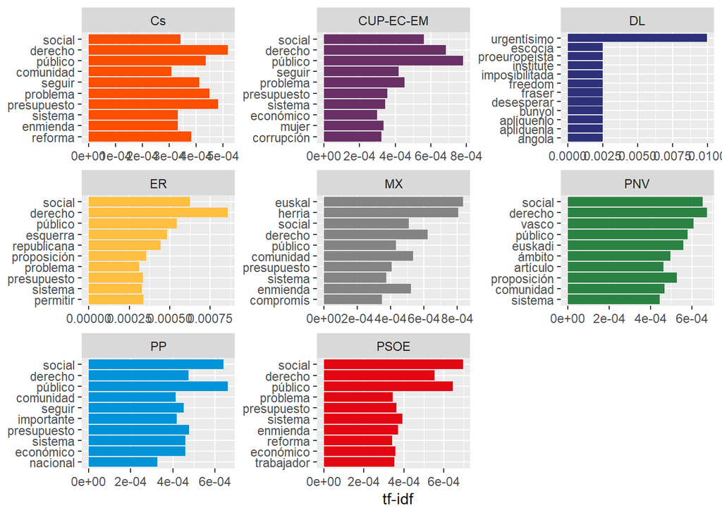

```r
speeches_2017 <- parsed_df_clean |>
  filter(year == 2017)

tfidf_2017 <- speeches_2017 |>
  count(party, word, sort = TRUE) |>
  bind_tf_idf(word, party, n) |>
  arrange(desc(tf_idf))

tfidf_2017 |>
  group_by(party) |>
  slice_max(tf_idf, n = 10) |>
  ungroup() |>
  ggplot(aes(tf_idf, fct_reorder(word, tf_idf), fill = party)) +
  geom_col(show.legend = FALSE) +
  facet_wrap(~ party, scales = "free") +
  scale_fill_manual(values = party_colors) +
  labs(x = "tf-idf", y = NULL)
```

### 2018

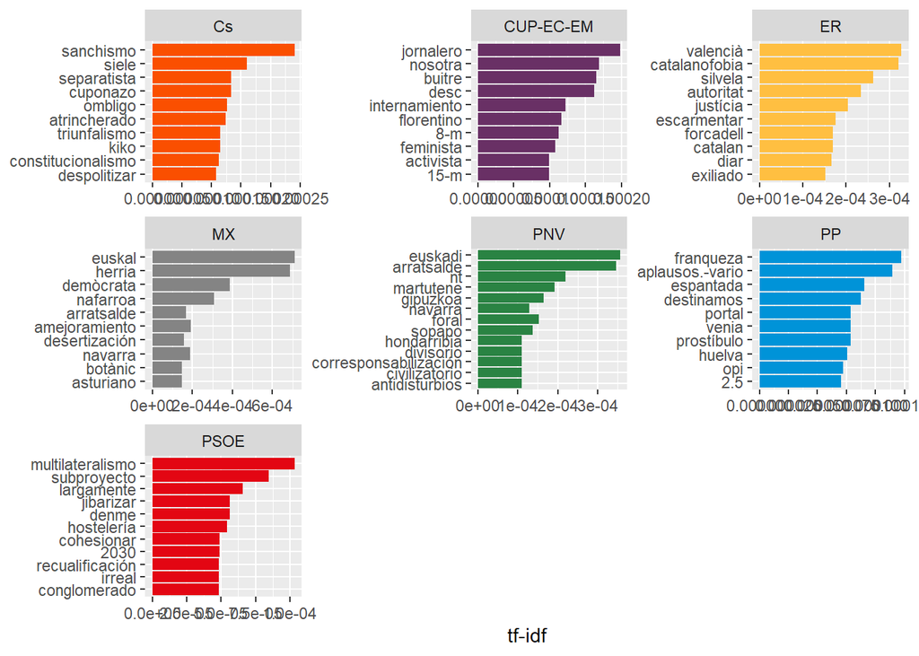

```r
speeches_2018 <- parsed_df_clean |>
  filter(year == 2018)

tfidf_2018 <- speeches_2018 |>
  count(party, word, sort = TRUE) |>
  bind_tf_idf(word, party, n) |>
  arrange(desc(tf_idf))

tfidf_2018 |>
  group_by(party) |>
  slice_max(tf_idf, n = 10) |>
  ungroup() |>
  ggplot(aes(tf_idf, fct_reorder(word, tf_idf), fill = party)) +
  geom_col(show.legend = FALSE) +
  facet_wrap(~ party, scales = "free") +
  scale_fill_manual(values = party_colors) +
  labs(x = "tf-idf", y = NULL)
```

## 3. Topic Modelling

### 3.1. STM

First, we need to prepare the data in the proper format for the STM to work. To do that we have to collapse all the words back together (STEM works with complete texts, not individual tokens).

```r
df_texts <- parsed_df_clean |>
  group_by(doc_id) |>
  summarise(text = paste(word, collapse = " ")) |>
  ungroup()
```

```r
df_meta <- parsed_df_clean |>
  select(doc_id, date, party, speaker) |>
  distinct()
```

Now let’s join both dataframes back together:

```r
df_combined <- df_texts |>
  left_join(df_meta, by = "doc_id")
```

Process the text and prepare the output:

```r
processed <- textProcessor(documents = df_combined$text,
                           metadata = df_combined,
                           removestopwords = FALSE,
                           removenumbers = FALSE,
                           removepunctuation = FALSE,
                           stem = FALSE,
                           language = "es")
```

```
Building corpus...
Converting to Lower Case...
Creating Output...
```

```r
out <- prepDocuments(processed$documents,
                     processed$vocab,
                     processed$meta)
```

```
Removing 21471 of 47784 terms (21471 of 1331395 tokens) due to frequency
Your corpus now has 10885 documents, 26313 terms and 1309924 tokens.
```

Train the model:

With four topics (k = 4):

```r
stm_model <- stm(documents = out$documents,
                 vocab = out$vocab,
                 data = out$meta,
                 K = 4,
                 prevalence = ~ party + s(as.numeric(date)),
                 seed = 1234)
```

Analyze the results:

```r
label_output <- labelTopics(stm_model, n = 10)

label_output
```

```
Topic 1 Top Words:
     Highest Prob: euros, país, millón, social, gobierno, empresa, pensión, económico, política, sector
     FREX: pensión, salario, energético, energía, salarial, industria, subida, desempleo, climático, eléctrico
     Lift: 1,1%, 1,3%, 1,8%, 1.35, 10/2017, 11.5, 1193, 12.5, 13.2, 16/2013
     Score: euros, pensión, millón, salario, energético, energía, economía, crecimiento, eléctrico, pensionista
Topic 2 Top Words:
     Highest Prob: ley, derecho, grupo, deber, persona, proposición, artículo, justicia, parlamentario, medida
     FREX: legislativo, código, toma, orgánica, ordenamiento, animal, sexual, eutanasia, convención, jurisdicción
     Lift: 016, 1.ª, 1/1979, 1/2004, 1/2007, 1/2009, 1/2013, 1/2015, 10.2, 10/1995
     Score: penal, judicial, código, tribunal, delito, víctima, justicia, directiva, artículo, proposición
Topic 3 Top Words:
     Highest Prob: gobierno, comunidad, presupuesto, público, autónomo, grupo, servicio, sistema, administración, política
     FREX: educativo, local, dependencia, alumno, peaje, lomce, universitario, escolar, docente, canario
     Lift: -¡claro, 0,7%, 0.16, 1.26, 10,6%, 1009, 1043, 1081, 109.2, 11200
     Score: presupuesto, educativo, inversión, educación, comunidad, local, millón, financiación, administración, profesorado
Topic 4 Top Words:
     Highest Prob: partido, gobierno, querer, hablar, español, popular, cataluña, país, político, creer
     FREX: referéndum, independentista, censura, 155, vergüenza, radiotelevisión, golpe, televisión, candidato, refugiado
     Lift: inmigración, -¡de, -¡fíjense, -¡oh, -¡por, -¿lo, -¿verdad, 1066, 17337, 1924
     Score: cataluña, democracia, referéndum, democrático, libertad, independentista, constitución, juez, censura, 155
```

- `prob`: most frequent words in each topic ➞ May include generic words (not so informative).
- `frex`: weighted harmonic mean of word frequency and exclusivity. It includes words that are both common in the topic and distinctive to it ➞ Most interpretable labeling method, so we will focus on this metric.
- `lift`: ratio of the probability of a word in the topic to the overall probability of the word in all topics. It finds the most exclusive words for each topic (highlights niche words, but may overemphasize rare or obscure terms).
- `score`: this metric “divides the log frequency of the word of the topic by the log frequency of the word in other topics” ➞ it help us find highly discriminative words.

```r
frex_df <- as.data.frame(label_output$frex) |>
  mutate(topic = row_number()) |>
  pivot_longer(cols = starts_with("V"),
               names_to = "rank",
               values_to = "term") |>
  mutate(rank = as.integer(gsub("V", "", rank))) |>
  arrange(topic, rank)
```

|  | topic | rank | term |
| --- | --- | --- | --- |
| 1 | 1 | 1 | pensión |
| 2 | 1 | 2 | salario |
| 3 | 1 | 3 | energético |
| 4 | 1 | 4 | energía |
| 5 | 1 | 5 | salarial |
| 6 | 1 | 6 | industria |
| 7 | 1 | 7 | subida |
| 8 | 1 | 8 | desempleo |
| 9 | 1 | 9 | climático |
| 10 | 1 | 10 | eléctrico |

[output cut: 30 more lines]

With 6 topics (k= 6):

```r
stm_model_6 <- stm(documents = out$documents,
                 vocab = out$vocab,
                 data = out$meta,
                 K = 6,
                 prevalence = ~ party + s(as.numeric(date)),
                 seed = 1234)
```

```r
label_output_6 <- labelTopics(stm_model_6, n = 10)

frex_df_6 <- as.data.frame(label_output_6$frex) |>
  mutate(topic = row_number()) |>
  pivot_longer(cols = starts_with("V"),
               names_to = "rank",
               values_to = "term") |>
  mutate(rank = as.integer(gsub("V", "", rank))) |>
  arrange(topic, rank)
```

| topic | rank | term |
| --- | --- | --- |
| 1 | 1 | energético |
| 1 | 2 | energía |
| 1 | 3 | rural |
| 1 | 4 | climático |
| 1 | 5 | eléctrico |
| 1 | 6 | industrial |
| 1 | 7 | vehículo |
| 1 | 8 | infancia |
| 1 | 9 | gas |
| 1 | 10 | ferroviario |

[output cut: 50 more lines]

**4 Topics**:

- Economic, social and energy policy.
- Miscellaneous topics.
- Education policy.
- Catalan Independence.

**6 Topics**:

- Energy transition and demographic challenge (España vaciada/rural).
- Economic/social policy and budgets (specially, pensions).
- Miscellaneous topics (broadcasting, disabilities, amendment, veto…)
- Justice and criminal law.
- Regional competencies: healthcare and education.
- catalan independence.

Let’s add them to our table:

```r
topic_labels <- c(
  "1" = "Energy transition & demographic challenge",
  "2" = "Economic/social policy & budgets",
  "3" = "Miscellaneous topics",
  "4" = "Justice & criminal law",
  "5" = "Regional competencies (healthcare and education)",
  "6" = "Catalan independence"
)

frex_df_6 <- frex_df_6 |>
  mutate(topic = as.character(topic)) |>
  mutate(label = topic_labels[topic]) |>
  relocate(label, .after = topic)
```

| topic | label | rank | term |
| --- | --- | --- | --- |
| 1 | Energy transition &amp; demographic challenge | 1 | energético |
| 1 | Energy transition &amp; demographic challenge | 2 | energía |
| 1 | Energy transition &amp; demographic challenge | 3 | rural |
| 1 | Energy transition &amp; demographic challenge | 4 | climático |
| 1 | Energy transition &amp; demographic challenge | 5 | eléctrico |
| 1 | Energy transition &amp; demographic challenge | 6 | industrial |
| 1 | Energy transition &amp; demographic challenge | 7 | vehículo |
| 1 | Energy transition &amp; demographic challenge | 8 | infancia |
| 1 | Energy transition &amp; demographic challenge | 9 | gas |
| 1 | Energy transition &amp; demographic challenge | 10 | ferroviario |

[output cut: 50 more lines]

```r
#save(stm_model_6, frex_df_6, processed, out, file = "DATA/stm_model_6.RData")
load("DATA/stm_model_6.RData")
```

**Topic distribution by party:**

```r
theta_df <- as.data.frame(stm_model_6$theta)
theta_df$party <- out$meta$party

theta_avg <- theta_df |>
  group_by(party) |>
  summarise(across(everything(), mean))

theta_long <- theta_avg |>
  pivot_longer(
    cols = -party,
    names_to = "topic",
    values_to = "proportion"
  ) |>
  mutate(topic = as.integer(gsub("V", "", topic))) |>
  left_join(
    frex_df_6 |>
      mutate(topic = as.integer(topic)) |>
      select(topic, label) |>
      distinct(),
    by = "topic"
  )
```

Visualization:

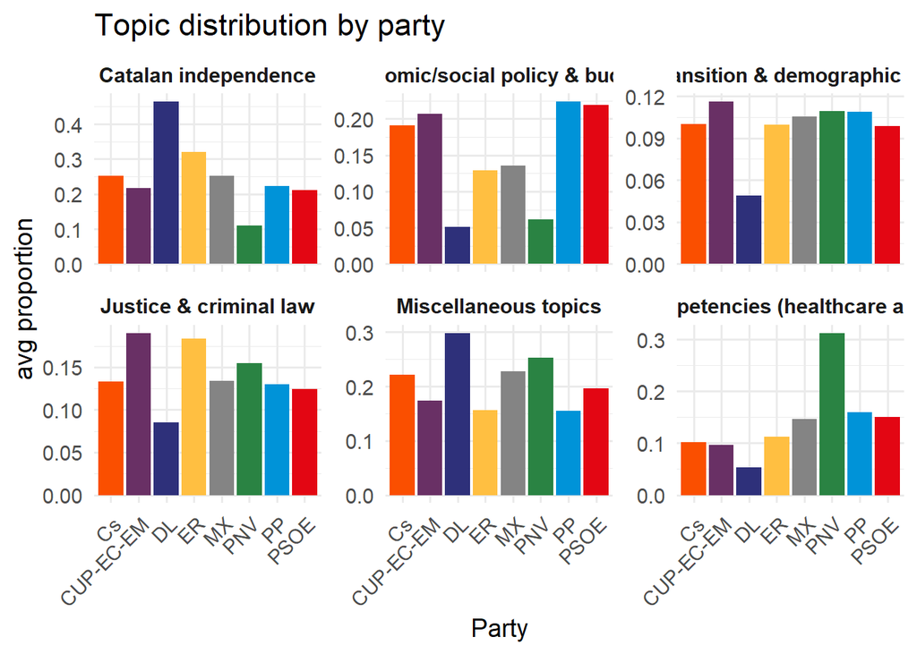

```r
ggplot(theta_long, aes(x = party, y = proportion, fill = party)) +
  geom_col(show.legend = FALSE) +
  facet_wrap(~ label, scales = "free_y") +
  labs(
    title = "Topic distribution by party",
    x = "Party",
    y = "avg proportion"
  ) +
  theme_minimal(base_size = 14) +
  scale_fill_manual(values = party_colors) +
  theme(
    axis.text.x = element_text(angle = 45, hjust = 1),
    strip.text = element_text(face = "bold")
  )
```

### 3.2. LDA

#### In total

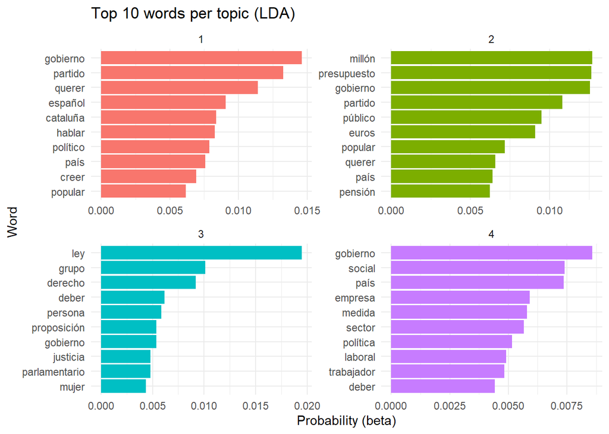

```r
# Create DTM
dtm <- parsed_df_clean |>
  count(doc_id, word, sort = TRUE) |>
  cast_dtm(document = doc_id, term = word, value = n)

# Apply LDA
lda_model <- LDA(dtm, k = 4, control = list(seed = 123))

# Extract the terms with tidytext
lda_terms <- tidy(lda_model, matrix = "beta")

# Select TOP 10 words with highest prob per topic
top_terms <- lda_terms |>
  group_by(topic) |>
  slice_max(order_by = beta, n = 10) |>
  ungroup()

# Visualize
top_terms |>
  mutate(term = reorder_within(term, beta, topic)) |>
  ggplot(aes(x = beta, y = term, fill = factor(topic))) +
  geom_col(show.legend = FALSE) +
  facet_wrap(~ topic, scales = "free") +
  scale_y_reordered() +
  labs(
    title = "Top 10 words per topic (LDA)",
    x = "Probability (beta)",
    y = "Word"
  ) +
  theme_minimal()
```

The words are too generic.